# Integrating scRNA-Seq datasets

The Data Lab for ALSF

2022

## Objectives

This notebook will demonstrate how to:

- Prepare SCE objects for integration
- Apply integration methods including `fastMNN` and `harmony`
- Visually explore the results of integration
- Learn skills in functional programming in the `tidyverse` with `purrr`

In this notebook, we’ll perform integration of several scRNA-seq datasets from the [Single-cell Pediatric Cancer Atlas (`ScPCA`)](https://scpca.alexslemonade.org/), a database of uniformly-processed pediatric scRNA-seq data built and maintained by the Data Lab. This database currently hosts projects from ten different ALSF-funded labs who have generated single-cell pediatric cancer transcriptomic data with the ultimate goal of making this data easily accessible to investigators (like you!).

Specifically, we’ll have a look at four libraries from the [`SCPCP000005` project](https://scpca.alexslemonade.org/projects/SCPCP000005), which contains rhabdomyosarcoma (RMS) data ([Patel *et al.* (2022)](https://doi.org/10.1016/j.devcel.2022.04.003)). This data is part of an overall project led by the [Dyer](https://www.stjude.org/research/labs/dyer-lab.html) and [Chen](https://www.stjude.org/research/labs/chen-lab-taosheng.html) labs at St. Jude Children’s Research Hospital to characterize the heterogeneity of pediatric solid tumors. The four libraries we’ll be looking were obtained from four different patients at recurrences and were sequenced as single-nuclei with 10Xv3 technology. These shared metadata properties hopefully make these datasets suitable for integration - it’s important to bear in mind that not all datasets can/will integrate.

We’ll be performing integration with two different tools, `fastmNN` and `harmony`. One reason we’re using two approaches is to compare their performance; as we might see (foreshadowing!), different methods may perform differently!

## Set Up

```r
# Load libraries
library(magrittr)
library(ggplot2)
library(SingleCellExperiment)
# Set the seed for reproducibility
set.seed(12345)
```

### Functional programming

We have already pre-processed count data for the four samples we’ll be integrating (i.e., filtered cells, normalized counts, and calculated PCA & UMAP). These pre-processed SCE objects, stored as RDS files, are available in the `data/rms/processed/` directory. Files are named according to their library IDs:

- `SCPCL000478.rds`
- `SCPCL000479.rds`
- `SCPCL000480.rds`
- `SCPCL000481.rds`

To read in these files, we could use `readr::read_rds()` (or the base R `readRDS()`) function four times, once for each of the files. A different and more modular coding approach to reading in these files (and more!) is to leverage the [`purrr`](https://purrr.tidyverse.org/) `tidyverse` package, which provides a convenient set of functions for *functional programming*. You can read more about functional programming in R in [Chapter 21 of *R for Data Science*](https://r4ds.had.co.nz/iteration.html#for-loops-vs.-functionals).

Of particular interest is the [`purrr::map()`](https://purrr.tidyverse.org/reference/map.html) family of functions, which can be used to run a given function on each element of a list or vector in one call. The general syntax for `purrr::map()` and friends is:

```
# Syntax for using the map function:
purrr::map(<input vector or list>,
           <function to apply to each item in the input>,
           <any additional arguments to the function can go here>,
           <and also here if there are even more arguments, and so on>)
```

Let’s see a very simple example in action by quickly taking the square root of a vector of values:

```r
squares <- c(4, 9, 16, 25, 36)

# The `map()` function always returns a list
purrr::map(squares, # vector to map over
           sqrt)    # function to apply to each item in `squares`
```

```
[[1]]
[1] 2

[[2]]
[1] 3

[[3]]
[1] 4

[[4]]
[1] 5

[[5]]
[1] 6
```

The output from running `purr::map()` is always a list (but note that there are other `purrr::map()` relatives which return other object types, as you can read about in [the `purrr::map()` documentation](https://purrr.tidyverse.org/reference/index.html)).

### Directories and files

Let’s set up our directories:

```r
# Define directory where integration data is stored
data_dir <- file.path("data", "rms", "processed")

# Output file name for the integrated object
integrated_sce_file <- file.path(data_dir, "integrated_sce.rds")
```

Now, let’s use `purrr::map()` to read in our SCE objects so that they are immediately stored together in a list. We’ll want to use the `readr::read_rds()` function to read in each file, so we’ll first need a vector of the file names we’ll be reading in. We can use the handy `list.files()` function to help us find the names of all relevant `.rds` files in the input directory.

```r
# Find all files matching our pattern of `SCPCL<numbers>` in `.rds` in the input directory
sce_paths <- list.files(data_dir,
                        # This regular expression forms the pattern: "SCPCL<numbers>rds"
                        pattern = "SCPCL\\d+.rds",
                        # return the relative paths to the files, not just the file names themselves
                        full.names = TRUE)
sce_paths
```

```
[1] "data/rms/processed/SCPCL000478.rds" "data/rms/processed/SCPCL000479.rds"
[3] "data/rms/processed/SCPCL000480.rds" "data/rms/processed/SCPCL000481.rds"
```

Now, let’s read those files into a single list:

```r
# Use purrr::map() to read all files into a list at once:
sce_list <- purrr::map(
  sce_paths,
  readr::read_rds
)
sce_list
```

```
[[1]]
class: SingleCellExperiment
dim: 60319 3013
metadata(14): salmon_version reference_index ... filtering_method miQC_model
assays(2): counts logcounts
rownames(60319): ENSG00000000003 ENSG00000000005 ... ENSG00000288724 ENSG00000288725
rowData names(3): gene_symbol mean detected
colnames(3013): CCTTTGGCACTACCCT GCAACCGGTCTTAGTG ... GGTAGAGCATTGAGCT GTCGTTCCACTACCCT
colData names(12): sum detected ... celltype_fine celltype_broad
reducedDimNames(2): PCA UMAP
mainExpName: NULL
altExpNames(0):

[[2]]
class: SingleCellExperiment
dim: 60319 1918
metadata(14): salmon_version reference_index ... filtering_method miQC_model
assays(2): counts logcounts
rownames(60319): ENSG00000000003 ENSG00000000005 ... ENSG00000288724 ENSG00000288725
rowData names(3): gene_symbol mean detected
colnames(1918): GGGACCTCAAGCGGAT CACAGATAGTGAGTGC ... GTTGTCCCACGTACAT TCCGATCGTCGTGCCA
colData names(12): sum detected ... celltype_fine celltype_broad
reducedDimNames(2): PCA UMAP
mainExpName: NULL
altExpNames(0):

[[3]]
class: SingleCellExperiment
dim: 60319 4428
metadata(14): salmon_version reference_index ... filtering_method miQC_model
assays(2): counts logcounts
rownames(60319): ENSG00000000003 ENSG00000000005 ... ENSG00000288724 ENSG00000288725
rowData names(3): gene_symbol mean detected
colnames(4428): TAGGGTTAGCAAGCCA AACTTCTTCCCTCAAC ... AGGGAGTAGCCTCATA TCGGATACATTGCAAC
colData names(12): sum detected ... celltype_fine celltype_broad
reducedDimNames(2): PCA UMAP
mainExpName: NULL
altExpNames(0):

[[4]]
class: SingleCellExperiment
dim: 60319 5236
metadata(14): salmon_version reference_index ... filtering_method miQC_model
assays(2): counts logcounts
rownames(60319): ENSG00000000003 ENSG00000000005 ... ENSG00000288724 ENSG00000288725
rowData names(3): gene_symbol mean detected
colnames(5236): TCATGAGAGGCCCACT GGGTATTTCGTTGTGA ... AAAGAACCACTTCAAG CAGCAGCTCGTGCATA
colData names(12): sum detected ... celltype_fine celltype_broad
reducedDimNames(2): PCA UMAP
mainExpName: NULL
altExpNames(0):
```

We now have a list of length four, where each item is a processed SCE object! However, we’ll need to keep track of which library each item is, so it’s helpful to add *names* to this list representing the relevant library names.

```r
# This code will extract the portion of each `sce_paths` string that matches
#  the library name specifically
stringr::str_extract_all(sce_paths, "SCPCL\\d+")
```

```
[[1]]
[1] "SCPCL000478"

[[2]]
[1] "SCPCL000479"

[[3]]
[1] "SCPCL000480"

[[4]]
[1] "SCPCL000481"
```

```r
# Assign the library names as the names for sce_list
names(sce_list) <- stringr::str_extract_all(sce_paths, "SCPCL\\d+")

sce_list
```

```
$SCPCL000478
class: SingleCellExperiment
dim: 60319 3013
metadata(14): salmon_version reference_index ... filtering_method miQC_model
assays(2): counts logcounts
rownames(60319): ENSG00000000003 ENSG00000000005 ... ENSG00000288724 ENSG00000288725
rowData names(3): gene_symbol mean detected
colnames(3013): CCTTTGGCACTACCCT GCAACCGGTCTTAGTG ... GGTAGAGCATTGAGCT GTCGTTCCACTACCCT
colData names(12): sum detected ... celltype_fine celltype_broad
reducedDimNames(2): PCA UMAP
mainExpName: NULL
altExpNames(0):

$SCPCL000479
class: SingleCellExperiment
dim: 60319 1918
metadata(14): salmon_version reference_index ... filtering_method miQC_model
assays(2): counts logcounts
rownames(60319): ENSG00000000003 ENSG00000000005 ... ENSG00000288724 ENSG00000288725
rowData names(3): gene_symbol mean detected
colnames(1918): GGGACCTCAAGCGGAT CACAGATAGTGAGTGC ... GTTGTCCCACGTACAT TCCGATCGTCGTGCCA
colData names(12): sum detected ... celltype_fine celltype_broad
reducedDimNames(2): PCA UMAP
mainExpName: NULL
altExpNames(0):

$SCPCL000480
class: SingleCellExperiment
dim: 60319 4428
metadata(14): salmon_version reference_index ... filtering_method miQC_model
assays(2): counts logcounts
rownames(60319): ENSG00000000003 ENSG00000000005 ... ENSG00000288724 ENSG00000288725
rowData names(3): gene_symbol mean detected
colnames(4428): TAGGGTTAGCAAGCCA AACTTCTTCCCTCAAC ... AGGGAGTAGCCTCATA TCGGATACATTGCAAC
colData names(12): sum detected ... celltype_fine celltype_broad
reducedDimNames(2): PCA UMAP
mainExpName: NULL
altExpNames(0):

$SCPCL000481
class: SingleCellExperiment
dim: 60319 5236
metadata(14): salmon_version reference_index ... filtering_method miQC_model
assays(2): counts logcounts
rownames(60319): ENSG00000000003 ENSG00000000005 ... ENSG00000288724 ENSG00000288725
rowData names(3): gene_symbol mean detected
colnames(5236): TCATGAGAGGCCCACT GGGTATTTCGTTGTGA ... AAAGAACCACTTCAAG CAGCAGCTCGTGCATA
colData names(12): sum detected ... celltype_fine celltype_broad
reducedDimNames(2): PCA UMAP
mainExpName: NULL
altExpNames(0):
```

If you look closely at the printed SCE objects, you may notice that they all contain colData columns `celltype_fine` and `celltype_broad`. These columns (which we added to SCE objects during pre-processing) contain putative *cell type annotations* as assigned in [Patel *et al.* (2022)](https://doi.org/10.1016/j.devcel.2022.04.003). We can leverage these cell type annotations to explore how successful our integration is: After integration, we expect cell types from different samples to cluster together, rather than being separated by batches.

Before we proceed, it’s critical to remember that integration procedures do *not actually use* these cell type annotations, and high-confidence annotations are not always (usually!) available for a given dataset. If we have annotations, they are a helpful “bonus” for assessing the integration’s success, but they are not necessary for performing integration, nor should you expect to always be able to assess integration using them.

## Prepare the SCE list for integration

> reviewer note: I need to make a diagram here to show areas in the SCE that need updating, and possibly also a before/after SCE sketch.

Now that we have a list of processed SCE objects, we need to merge the objects into one overall SCE object which we can provide as input to integration methods. A word of caution before we begin: **This merged SCE object is NOT an integrated SCE!**

To merge SCE objects, we do need to do some wrangling and bookkeeping to ensure compatibility and that we don’t lose important information. Overall we’ll need to take care of these items:

- We should be able to trace library-specific information back to its originating library, including…
  - Library-specific statistics, e.g. gene-level statistics for a given library found in `rowData`
  - Cell-level information: Which library is each cell from?
- SCE objects should contain the same genes. In other words, each `rowData` table should have the same rownames.
- SCE columns should match. In other words, the each `colData` should have the same column names.

First, let’s determine what the shared genes among SCE objects are using some `purrr` magic. Ultimately, we’ll filter SCEs down to contain only these genes, thereby ensuring that their genes match.

```r
shared_genes <- sce_list %>%
  # get rownames for each SCE in sce_list
  purrr::map(rownames) %>%
  # reduce to the _intersection_ among lists
  purrr::reduce(intersect)

# Vector of genes that are present across all SCEs
head(shared_genes)
```

```
[1] "ENSG00000000003" "ENSG00000000005" "ENSG00000000419" "ENSG00000000457" "ENSG00000000460"
[6] "ENSG00000000938"
```

In this case, all SCE objects we’re working with actually already contained the same genes, but it can’t hurt to be sure! To confirm this, we can check that `shared_genes` is the same size as the genes in each SCE:

```r
# How many shared genes?
length(shared_genes)
```

```
[1] 60319
```

```r
# How many genes in each SCE?
# Same number as the shared genes all around!
genes_per_sce <- sce_list %>%
  purrr::map(rownames) %>%
  purrr::map(length)
```

[output not shown]

Next, lets see how the `colData` columns compare across SCEs:

```r
# What are the colData names?
# Note the slightly different syntax here: We're providing a formula!
purrr::map(sce_list,
           ~names(colData(.)))
```

```
$SCPCL000478
 [1] "sum"                   "detected"              "subsets_mito_sum"      "subsets_mito_detected"
 [5] "subsets_mito_percent"  "total"                 "prob_compromised"      "miQC_pass"
 [9] "sizeFactor"            "barcode"               "celltype_fine"         "celltype_broad"

$SCPCL000479
 [1] "sum"                   "detected"              "subsets_mito_sum"      "subsets_mito_detected"
 [5] "subsets_mito_percent"  "total"                 "prob_compromised"      "miQC_pass"
 [9] "sizeFactor"            "barcode"               "celltype_fine"         "celltype_broad"

$SCPCL000480
 [1] "sum"                   "detected"              "subsets_mito_sum"      "subsets_mito_detected"
 [5] "subsets_mito_percent"  "total"                 "prob_compromised"      "miQC_pass"
 [9] "sizeFactor"            "barcode"               "celltype_fine"         "celltype_broad"

$SCPCL000481
 [1] "sum"                   "detected"              "subsets_mito_sum"      "subsets_mito_detected"
 [5] "subsets_mito_percent"  "total"                 "prob_compromised"      "miQC_pass"
 [9] "sizeFactor"            "barcode"               "celltype_fine"         "celltype_broad"
```

```r
# Some purrr magic can quickly show us any differences
#  among column names
purrr::map(sce_list,
           ~names(colData(.))) %>%
  # Reduce to the _difference_ among lists
  purrr::reduce(setdiff)
```

```
character(0)
```

It looks like the columns are all already matching among SCEs, so we can leave all of this alone!

Now, let’s look at `rowData` to see where we might need to wrangle there:

```r
purrr::map(sce_list,
           ~names(rowData(.)))
```

```
$SCPCL000478
[1] "gene_symbol" "mean"        "detected"

$SCPCL000479
[1] "gene_symbol" "mean"        "detected"

$SCPCL000480
[1] "gene_symbol" "mean"        "detected"

$SCPCL000481
[1] "gene_symbol" "mean"        "detected"
```

Each SCE object has the same 3 `rowData` columns: `gene_symbol`, `mean`, and `detected`. The first column is general information not specific to any library or experiment, but `mean` and `detected` are library-specific information containing gene statistics. So, `gene_symbol` does not need to be traced back to its originating library, but `mean` and `detected` do. We can ensure these columns remain distinguishable by *prepending the library name* to library-specific columns. For example, rather than being called `mean`, we could update this column’s name to `<library>-mean` (e.g. `SCPCL000478-mean` for the `SCPCL000478` library).

Finally, how will we be able to tell the original library that each cell in the merged SCE came from? There are two modifications that we can do to ensure we’ll be able to track this information:

- We can add a column `sample` to the SCE object that directly stores the given library name, which will also be used as input to integration methods.
- The cell barcodes themselves (which are stored as `colData` rownames) can be modified to include library information
  - For example (a hypothetical) barcode `ACGTACGTACGT` might be renamed to `SCPCL000478-ACGTACGTACGT`, thereby preserving both library and barcode information for the cell.

As you can see, there’s a lot of moving parts to consider! It’s very important to take the time to explore the contents of your SCE objects so you know what needs to be tweaked, as this may be different for different SCEs.

Now that we know what needs to be modified, we can prepare the SCE objects for merging (again, this is not yet integrating!). We can in fact write our own function to format a single SCE based on our exploration, and then use `purrr::map()` to quickly apply this function to the whole `sce_list`. It’s important to note that this is not necessarily a function for general use - it’s been written to match the processing we need to do for *these* SCEs, and different SCEs in the wild will require different types of processing.

```r
# Note for reviewers - I suggest this NOT be a live chunk!
format_sce <- function(sce, library_name, shared_genes) {


  ###### Add in sample-level information as stand-alone column ######
  colData(sce)$sample <- library_name


  ###### Ensure cells can be identified ######
  # Update the colData row names by prepending {library_name}
  rownames(colData(sce)) <- glue::glue("{library_name}-{rownames(colData(sce))}")


  ###### Subset the SCE object to only contain the shared genes ######
  sce <- sce[shared_genes,]

  ###### Ensure gene-level stats can be identified ######
  # We want to rename the columns `mean` and `detected` to contain the {library_name}
  # Recall the names are: "gene_symbol", "mean", "detected"
  names(rowData(sce)) <- c("gene_symbol",
                           glue::glue("{library_name}-mean"),
                           glue::glue("{library_name}-detected"))

  # Return the formatted SCE object
  return(sce)
}
```

To run this function, we’ll use the convenient `purrr::imap()` function, which automatically fills in the second argument to the function we’re calling with the list names:

```r
sce_list_formatted <- purrr::imap(
  sce_list,
  format_sce,
  shared_genes = shared_genes
)
sce_list_formatted
```

```
$SCPCL000478
class: SingleCellExperiment
dim: 60319 3013
metadata(14): salmon_version reference_index ... filtering_method miQC_model
assays(2): counts logcounts
rownames(60319): ENSG00000000003 ENSG00000000005 ... ENSG00000288724 ENSG00000288725
rowData names(3): gene_symbol SCPCL000478-mean SCPCL000478-detected
colnames(3013): SCPCL000478-CCTTTGGCACTACCCT SCPCL000478-GCAACCGGTCTTAGTG ...
  SCPCL000478-GGTAGAGCATTGAGCT SCPCL000478-GTCGTTCCACTACCCT
colData names(13): sum detected ... celltype_broad sample
reducedDimNames(2): PCA UMAP
mainExpName: NULL
altExpNames(0):

$SCPCL000479
class: SingleCellExperiment
dim: 60319 1918
metadata(14): salmon_version reference_index ... filtering_method miQC_model
assays(2): counts logcounts
rownames(60319): ENSG00000000003 ENSG00000000005 ... ENSG00000288724 ENSG00000288725
rowData names(3): gene_symbol SCPCL000479-mean SCPCL000479-detected
colnames(1918): SCPCL000479-GGGACCTCAAGCGGAT SCPCL000479-CACAGATAGTGAGTGC ...
  SCPCL000479-GTTGTCCCACGTACAT SCPCL000479-TCCGATCGTCGTGCCA
colData names(13): sum detected ... celltype_broad sample
reducedDimNames(2): PCA UMAP
mainExpName: NULL
altExpNames(0):

$SCPCL000480
class: SingleCellExperiment
dim: 60319 4428
metadata(14): salmon_version reference_index ... filtering_method miQC_model
assays(2): counts logcounts
rownames(60319): ENSG00000000003 ENSG00000000005 ... ENSG00000288724 ENSG00000288725
rowData names(3): gene_symbol SCPCL000480-mean SCPCL000480-detected
colnames(4428): SCPCL000480-TAGGGTTAGCAAGCCA SCPCL000480-AACTTCTTCCCTCAAC ...
  SCPCL000480-AGGGAGTAGCCTCATA SCPCL000480-TCGGATACATTGCAAC
colData names(13): sum detected ... celltype_broad sample
reducedDimNames(2): PCA UMAP
mainExpName: NULL
altExpNames(0):

$SCPCL000481
class: SingleCellExperiment
dim: 60319 5236
metadata(14): salmon_version reference_index ... filtering_method miQC_model
assays(2): counts logcounts
rownames(60319): ENSG00000000003 ENSG00000000005 ... ENSG00000288724 ENSG00000288725
rowData names(3): gene_symbol SCPCL000481-mean SCPCL000481-detected
colnames(5236): SCPCL000481-TCATGAGAGGCCCACT SCPCL000481-GGGTATTTCGTTGTGA ...
  SCPCL000481-AAAGAACCACTTCAAG SCPCL000481-CAGCAGCTCGTGCATA
colData names(13): sum detected ... celltype_broad sample
reducedDimNames(2): PCA UMAP
mainExpName: NULL
altExpNames(0):
```

Since we need to apply `cbind()` to a *list* of objects, we need to use some slightly-gnarly syntax: We’ll use the function `do.call()`, which allows the `cbind()` input to be a list of objects to combine.

```r
merged_sce <- do.call(cbind, sce_list_formatted)
merged_sce
```

```
class: SingleCellExperiment
dim: 60319 14595
metadata(56): salmon_version reference_index ... filtering_method miQC_model
assays(2): counts logcounts
rownames(60319): ENSG00000000003 ENSG00000000005 ... ENSG00000288724 ENSG00000288725
rowData names(9): gene_symbol SCPCL000478-mean ... SCPCL000481-mean SCPCL000481-detected
colnames(14595): SCPCL000478-CCTTTGGCACTACCCT SCPCL000478-GCAACCGGTCTTAGTG ...
  SCPCL000481-AAAGAACCACTTCAAG SCPCL000481-CAGCAGCTCGTGCATA
colData names(13): sum detected ... celltype_broad sample
reducedDimNames(2): PCA UMAP
mainExpName: NULL
altExpNames(0):
```

We now have a single SCE object that contains all cells from all libraries we’d like to integrate.

## Integration

### First, explore! (needs better title?)

You might have noticed that that there are already `PCA` and `UMAP` dimension reductions in the merged SCE we created. These represent the original dimension reductions that were performed on *each individual library*.

We can also calculate PCA and UMAP for the merged SCE as a whole, which we will save with different names `merged_PCA` and `merged_UMAP` to distinguish them for the original. When calculating PCs on this merged object, we will want to use a slightly different approach that respects the batch differences within. We can compare these UMAP embeddings to those calculated after performing integration.

First, as usual we’ll create our vector of high-variance genes to use for calculations.

```r
# calculate high-variance genes to use for dimension reduction
gene_variance <- scran::modelGeneVar(merged_sce,
                                     # specify the grouping/batch column:
                                     block = merged_sce$sample)
hv_list <- scran::getTopHVGs(gene_variance,
                              n = 2000)
```

Next, we need to calculate PCs. Since we’re calculating PCs specifically on a merged object, we will want to use a slightly different approach that respects the batch differences within. Once we have PCs, we can proceed to calculate UMAP.

```r
# Use batchelor to calculate PCA from a merged group fo SCEs
multi_pca <- batchelor::multiBatchPCA(merged_sce,
                                      subset.row = hv_list,
                                      batch = merged_sce$sample,
                                      preserve.single = TRUE)

# add PCA results to merged SCE object
reducedDim(merged_sce, "merged_PCA") <- multi_pca[[1]]

# add merged_UMAP from merged_PCA
merged_sce <- scater::runUMAP(merged_sce,
                              dimred = "merged_PCA",
                              name = "merged_UMAP")

merged_sce
```

```
class: SingleCellExperiment
dim: 60319 14595
metadata(56): salmon_version reference_index ... filtering_method miQC_model
assays(2): counts logcounts
rownames(60319): ENSG00000000003 ENSG00000000005 ... ENSG00000288724 ENSG00000288725
rowData names(9): gene_symbol SCPCL000478-mean ... SCPCL000481-mean SCPCL000481-detected
colnames(14595): SCPCL000478-CCTTTGGCACTACCCT SCPCL000478-GCAACCGGTCTTAGTG ...
  SCPCL000481-AAAGAACCACTTCAAG SCPCL000481-CAGCAGCTCGTGCATA
colData names(13): sum detected ... celltype_broad sample
reducedDimNames(4): PCA UMAP merged_PCA merged_UMAP
mainExpName: NULL
altExpNames(0):
```

Let’s first see how these uncorrected UMAPs compare:

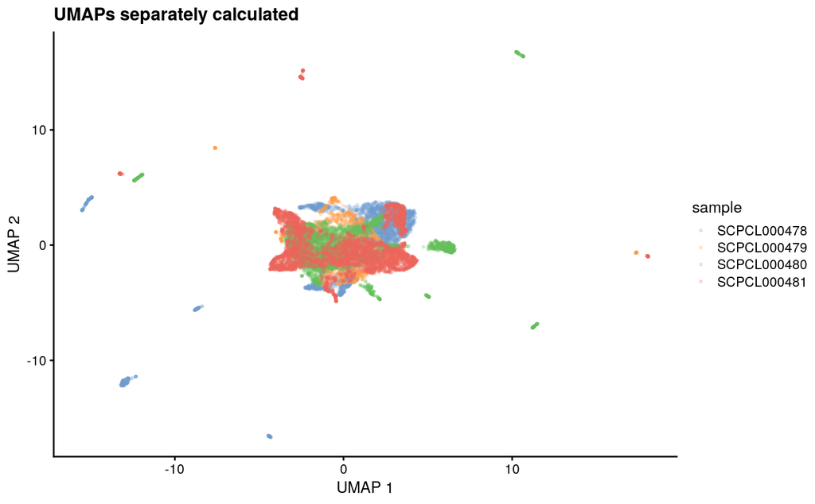

```r
# UMAPs scaled separately when calculated from individual libraries:
scater::plotReducedDim(merged_sce,
                       dimred = "UMAP",
                       colour_by = "sample",
                       # Some styling to help us see the points:
                       point_size = 0.5,
                       point_alpha = 0.2) +
  ggplot2::ggtitle("UMAPs separately calculated")
```

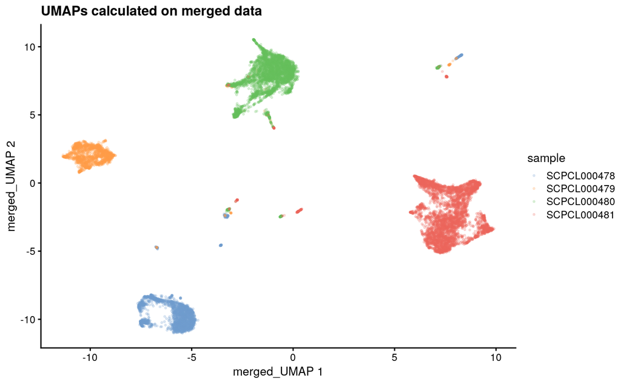

```r
# UMAPs scaled together when calculated from the merged SCE
scater::plotReducedDim(merged_sce,
                       dimred = "merged_UMAP",
                       colour_by = "sample",
                       # Some styling to help us see the points:
                       point_size = 0.5,
                       point_alpha = 0.2) +
  ggplot2::ggtitle("UMAPs calculated on merged data")
```

The main “clustering” (not technical clustering, just what we see visually!) in these plots are the batches. A well-integrated dataset will instead show much more mixing among batches, as the batch effects will have hopefully been corrected. How might you expect an integrated UMAP to look?

### Integration with `fastMNN`

Finally, we’re ready to integrate! To start, we’ll use the `fastMNN` approach from the Bioconductor [`batchelor` package](http://www.bioconductor.org/packages/3.16/bioc/html/batchelor.html). As the name suggests, this method is pretty fast! It returns a new SCE object containing integrated results:

```r
integrated_sce <- batchelor::fastMNN(
  # the merged SCE object
  merged_sce,
  # vector indicating the batches, which we created as `$sample` when formatting SCEs
  batch = merged_sce$sample,
  # Optionally, we can specify genes to use as the previously-ID'd
  #  high variance genes
  subset.row = hv_list
)

# Let's have a look!
integrated_sce
```

```
class: SingleCellExperiment
dim: 2000 14595
metadata(2): merge.info pca.info
assays(1): reconstructed
rownames(2000): ENSG00000157168 ENSG00000278996 ... ENSG00000197763 ENSG00000162244
rowData names(1): rotation
colnames(14595): SCPCL000478-CCTTTGGCACTACCCT SCPCL000478-GCAACCGGTCTTAGTG ...
  SCPCL000481-AAAGAACCACTTCAAG SCPCL000481-CAGCAGCTCGTGCATA
colData names(1): batch
reducedDimNames(1): corrected
mainExpName: NULL
altExpNames(0):
```

There are couple pieces of information here of interest:

- The new `reconstructed` assay represents the batch-corrected normalized expression values. While these are calculated and used during integration, they are **NOT** stand-alone values that you should use for other applications, e.g. differential gene expression.
- The new `corrected` reduced dimension represents the principle components (PCs) of these corrected expression values.

To conveniently keep everything in one place, let’s add these PCs information (with an informative name!) into our `merged_sce` object:

```r
# Make a new reducedDim named fastMNN_PCA from the corrected reducedDim in integrated_sce
reducedDim(merged_sce, "fastMNN_PCA") <- reducedDim(integrated_sce, "corrected")

merged_sce
```

```
class: SingleCellExperiment
dim: 60319 14595
metadata(56): salmon_version reference_index ... filtering_method miQC_model
assays(2): counts logcounts
rownames(60319): ENSG00000000003 ENSG00000000005 ... ENSG00000288724 ENSG00000288725
rowData names(9): gene_symbol SCPCL000478-mean ... SCPCL000481-mean SCPCL000481-detected
colnames(14595): SCPCL000478-CCTTTGGCACTACCCT SCPCL000478-GCAACCGGTCTTAGTG ...
  SCPCL000481-AAAGAACCACTTCAAG SCPCL000481-CAGCAGCTCGTGCATA
colData names(13): sum detected ... celltype_broad sample
reducedDimNames(5): PCA UMAP merged_PCA merged_UMAP fastMNN_PCA
mainExpName: NULL
altExpNames(0):
```

Finally, we’ll calculate UMAPs from these corrected PCs and plot them so we can see how qualitatively successful integration was:

```r
# Calculate UMAP
merged_sce <- scater::runUMAP(
  merged_sce,
  # create UMAP from these PCs:
  dimred = "fastMNN_PCA",
  # name the UMAP:
  name = "fastMNN_UMAP"
)
```

First, let’s plot the integrated UMAP highlighting the different batches. A well-integrated dataset will show batch mixing, but a poorly-integrated dataset will show more separation among batches, similar to the uncorrected UMAP.

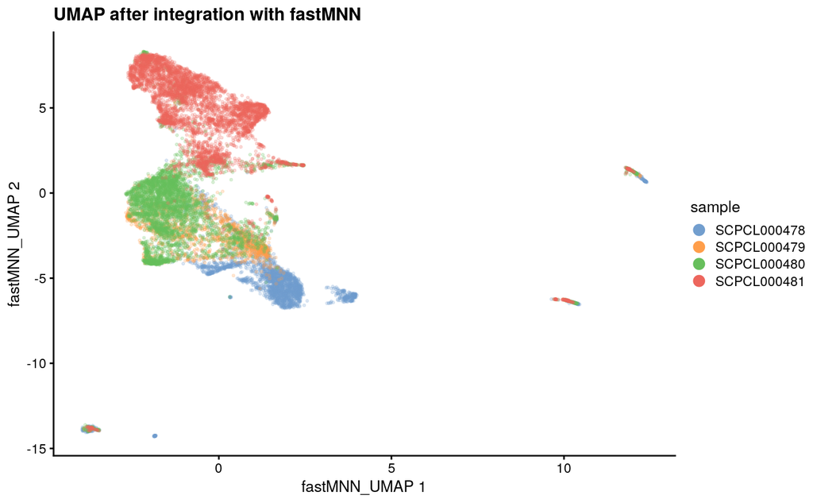

```r
scater::plotReducedDim(merged_sce,
                       # plot the fastMNN coordinates
                       dimred = "fastMNN_UMAP",
                       # color by sample (batch)
                       colour_by = "sample",
                       # Some styling to help us see the points:
                       point_size = 0.5,
                       point_alpha = 0.2) +
  ggplot2::ggtitle("UMAP after integration with fastMNN") +
  # Modify the ggplot2 guides so that the legend points are larger and easier to see:
  ggplot2::guides(colour = ggplot2::guide_legend(override.aes = list(size = 3, alpha = 1)))
```

Importantly, one reason that batches may still appear separated in the corrected UMAP is if they *should* be separated - for example, maybe two batches contain very different cell types. In this case, we would not expect batches to mix heavily, since their cell types should retain some structure. Recall from earlier, we conveniently have cell type annotations in our SCEs, so we can explore this here! We can re-plot this UMAP to highlight cell types: A well-integrated dataset will show cell types grouped together.

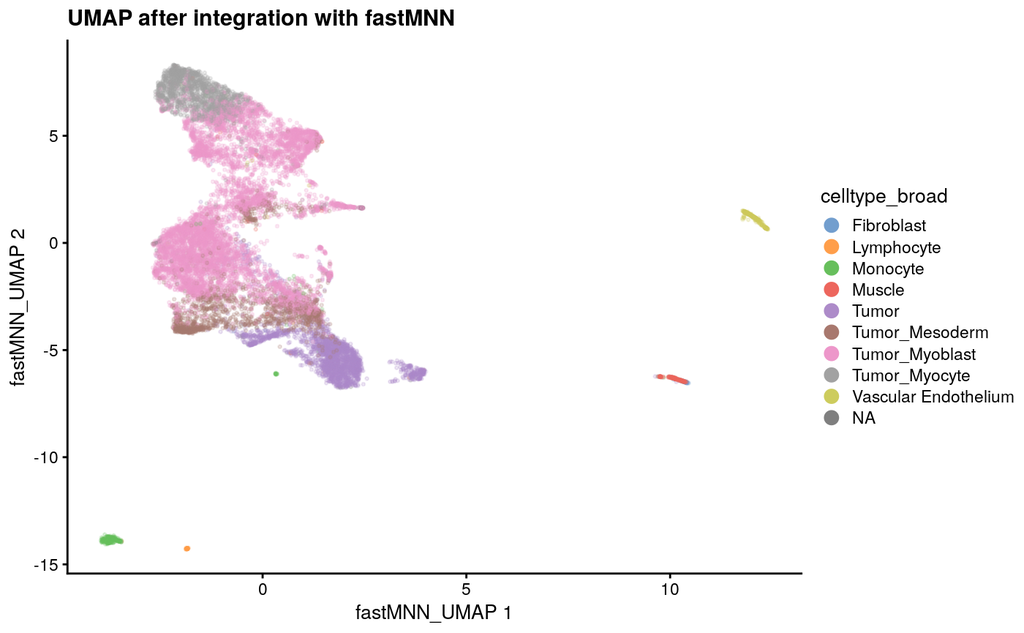

```r
scater::plotReducedDim(merged_sce,
                       # plot the fastMNN coordinates
                       dimred = "fastMNN_UMAP",
                       # color by broad celltypes
                       colour_by = "celltype_broad",
                       # Some styling to help us see the points:
                       point_size = 0.5,
                       point_alpha = 0.2) +
  ggplot2::ggtitle("UMAP after integration with fastMNN") +
  # Modify the ggplot2 guides so that the legend points are larger and easier to see:
  ggplot2::guides(colour = ggplot2::guide_legend(override.aes = list(size = 3, alpha = 1)))
```

### Integration with `harmony`

`fastMNN` is only one of many approaches to perform integration, and different methods are not unlikely to give different results! For contrast, let’s see how integration performs when using the [`harmony` method](https://portals.broadinstitute.org/harmony/) instead, which is available from the `harmony` CRAN package.

Algorithmic differences aside, there are a couple practical differences between `fastMNN` and `harmony` to be aware of:

- Unlike `fastMNN`, `harmony` allows you to specify additional covariates (e.g., technology, patient, diagnosis, etc.)
  - This requires slightly more setup that what we will show below.
- Unlike `fastMNN`, `harmony` does not calculate corrected expression values nor does it return an SCE object. Instead, it directly returns a matrix of corrected PCs.

```r
harmony_pcs <- harmony::HarmonyMatrix(
  # Provide the uncorrected PCs:
  data_mat  = reducedDim(merged_sce, "merged_PCA"),
  # Provide the batch information:
  meta_data = colData(merged_sce)$sample,
  # Set do_pca = FALSE since we are passing in PCs directly
  do_pca = FALSE
)
```

```
Harmony 1/10
Harmony 2/10
Harmony converged after 2 iterations
```

```r
# The result is just the PCs!
harmony_pcs[1:5, 1:5]
```

```
                                   [,1]       [,2]      [,3]      [,4]       [,5]
SCPCL000478-CCTTTGGCACTACCCT -2.2077930  2.3003925  1.655883  2.883425  -3.512563
SCPCL000478-GCAACCGGTCTTAGTG -2.7568000  0.7516537 -2.670128 -4.561354  -5.223138
SCPCL000478-TCACTATCAAATCCCA -1.2209295  9.2330526  5.945003  2.559605 -20.701387
SCPCL000478-TATATCCCACTCTCGT -0.9137878 10.6432606  7.647738  4.348491 -25.339549
SCPCL000478-GCACTAACATTACGGT -3.2240258  1.8626756 -3.494730 -1.845999  -6.275617
```

```r
# Let's store this directly into our `merged_sce` object, making sure to name it well!
reducedDim(merged_sce, "harmony_PCA") <- harmony_pcs

# As before, calculate UMAP on these PCs:
merged_sce <- scater::runUMAP(merged_sce,
                              dimred = "harmony_PCA",
                              name = "harmony_UMAP")
```

Let’s see how the `harmony` UMAP, colored by either batch or cell type, looks compared to the `fastMNN` UMAP:

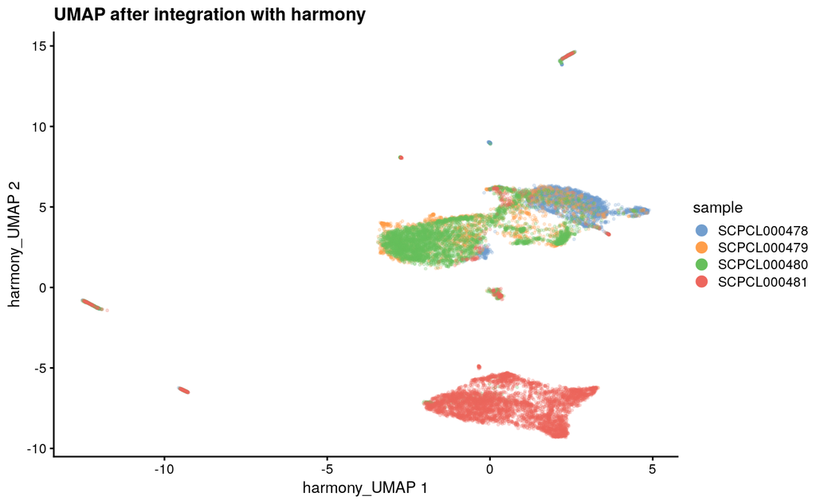

```r
scater::plotReducedDim(merged_sce,
                       # plot the harmony coordinates
                       dimred = "harmony_UMAP",
                       # color by sample (batch)
                       colour_by = "sample",
                       # Some styling to help us see the points:
                       point_size = 0.5,
                       point_alpha = 0.2) +
  ggplot2::ggtitle("UMAP after integration with harmony") +
  # Modify the ggplot2 guides so that the legend points are larger and easier to see:
  ggplot2::guides(colour = ggplot2::guide_legend(override.aes = list(size = 3, alpha = 1)))
```

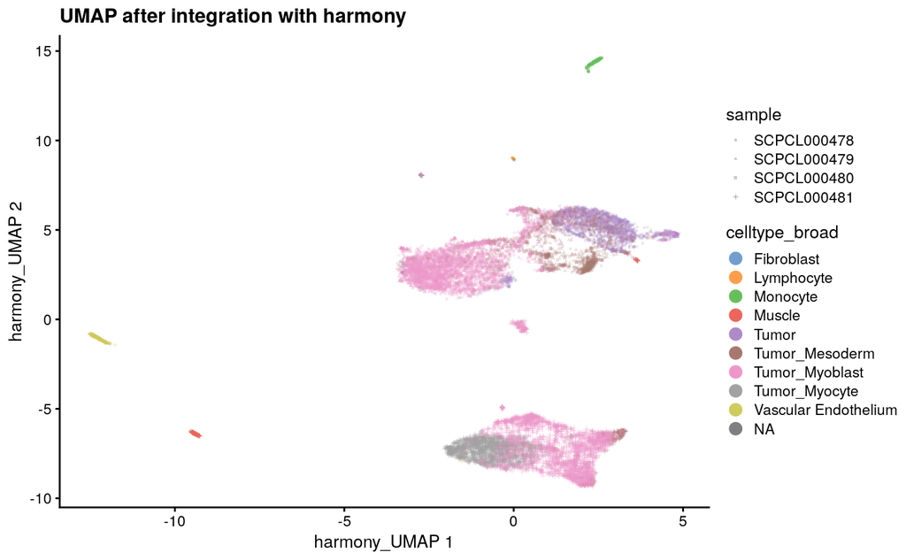

```r
scater::plotReducedDim(merged_sce,
                       # plot the harmony coordinates
                       dimred = "harmony_UMAP",
                       # color by broad celltypes
                       colour_by = "celltype_broad",
                       # Let's also shape by the batches:
                       shape_by = "sample",
                       # Some styling to help us see the points:
                       point_size = 0.5,
                       point_alpha = 0.2) +
  ggplot2::ggtitle("UMAP after integration with harmony") +
  # Modify the ggplot2 guides so that the legend points are larger and easier to see:
  ggplot2::guides(colour = ggplot2::guide_legend(override.aes = list(size = 3, alpha = 1)))
```

How do you think these methods’ (`fastMNN` and `harmony`) performances compare on these data?

Let’s now save our final SCE object to a file:

```r
# I'm getting disk space errors? but the file is being written? weird stuff.
#readr::write_rds(merged_sce, integrated_sce_file)
```

## Print session info

As always, we’ll print the session info to be transparent about what packages, and which versions, were used during this R session.

[session information not shown]